# DTSA 5510 Final Project

Author: Tyler B.

2023 Spring 1 Semester

## Project Description

For my unsupervised learning project, I chose to work on a clustering problem. While this class covered clustering in Week 2, I wanted to study clustering more in depth. Specifically, I wanted the chance to experiment with Gaussian Mixture Models, which is a popular clustering model that was not taught in this class. In my work as a Data Scientist, I have seen clustering problems pop up, and I would love to have a better understanding of the solutions that are available!

## Data Description

My dataset comes from Kaggle and can be found here: https://www.kaggle.com/competitions/tabular-playground-series-jul-2022/data

The problem is a classic unsupervised clustering problem. See the data description from the kaggle site below

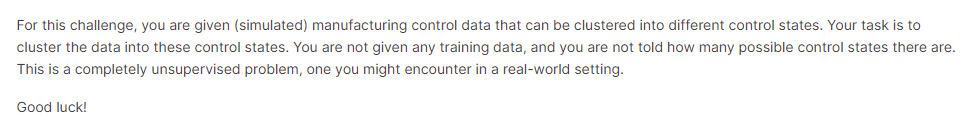

## Problem Statement

As the data description states, the problem at hand relates to manufacturing control data. Specifically, I will seek to cluster observations from a manufacturing process into different manufacturing control states. If this can be done, then we can deduce what control state a process is in based off the readings we are getting from the process.

## Project Setup

Before we can begin with EDA, we must first get our notebook set-up. I am doing my analysis on Google Colab, which means that I must pip install my packages with each session. As a result, I will first pip install pyclustering

```python
!pip install pyclustering --quiet
```

```
     ━━━━━━━━━━━━━━━━━━━━━━━━━━━━━━━━━━━━━━━━ 2.6/2.6 MB 6.7 MB/s eta 0:00:00
  Preparing metadata (setup.py) ... done
```

Next, I will import the needed packages and set the random seed.

```python
import pandas as pd
import matplotlib.pyplot as plt
import numpy as np
import math
import seaborn as sns

from sklearn.cluster import KMeans
from sklearn.metrics import silhouette_score
from sklearn.mixture import GaussianMixture
from sklearn.decomposition import PCA
from pyclustering.cluster.center_initializer import kmeans_plusplus_initializer
from pyclustering.cluster.kmeans import kmeans
from pyclustering.utils.metric import distance_metric
from sklearn.mixture import BayesianGaussianMixture
```

```python
# Set random seed
seed = 22
```

## Exploratory Data Analysis (EDA)

As with any data science problem, it is important to start with EDA to get an understanding of the data. I will first load in the data into a dataframe from a csv that has been downloaded from the kaggle site.

```python
# Load in data for project
df_with_id = pd.read_csv("data.csv")
df = df_with_id.drop(columns='id')
print(df.head())
```

```
       f_00      f_01      f_02      f_03      f_04      f_05      f_06  f_07  \
0 -0.389420 -0.912791  0.648951  0.589045 -0.830817  0.733624  2.258560     2
1 -0.689249 -0.453954  0.654175  0.995248 -1.653020  0.863810 -0.090651     2
2  0.809079  0.324568 -1.170602 -0.624491  0.105448  0.783948  1.988301     5
3 -0.500923  0.229049  0.264109  0.231520  0.415012 -1.221269  0.138850     6
4 -0.671268 -1.039533 -0.270155 -1.830264 -0.290108 -1.852809  0.781898     8

   f_08  f_09  ...      f_19      f_20      f_21      f_22      f_23  \
0    13    14  ... -0.478412 -0.757002 -0.763635 -1.090369  1.142641
1     3     6  ... -0.428791 -0.089908 -1.784204 -0.839474  0.459685
2    11     5  ... -0.413534 -1.602377  1.190984  3.267116 -0.088322
3     2    13  ...  0.619283  1.287801  0.532837  1.036631 -2.041828
4     7     5  ... -1.628830 -0.434948  0.322505  0.284326 -2.438365

       f_24      f_25      f_26      f_27      f_28
0 -0.884274  1.137896  1.309073  1.463002  0.813527
1  1.759412 -0.275422 -0.852168  0.562457 -2.680541
2 -2.168635 -0.974989  1.335763 -1.110655 -3.630723
3  1.440490 -1.900191 -0.630771 -0.050641  0.238333
4  1.473930 -1.044684  1.602686 -0.405263 -1.987263

[5 rows x 29 columns]
```

Next, I will print some summary statistics for my dataset.

```python
# Print different summary things
print(df.shape) # for dimensions of dataframe
print(df.info()) # shows datatypes and non null counts
print(df.describe()) # gives summary stats for numeric values
```

```
(98000, 29)
<class 'pandas.core.frame.DataFrame'>
RangeIndex: 98000 entries, 0 to 97999
Data columns (total 29 columns):
 #   Column  Non-Null Count  Dtype
---  ------  --------------  -----
 0   f_00    98000 non-null  float64
 1   f_01    98000 non-null  float64
 2   f_02    98000 non-null  float64
 3   f_03    98000 non-null  float64
 4   f_04    98000 non-null  float64
 5   f_05    98000 non-null  float64
 6   f_06    98000 non-null  float64
 7   f_07    98000 non-null  int64
 8   f_08    98000 non-null  int64
 9   f_09    98000 non-null  int64
 10  f_10    98000 non-null  int64
 11  f_11    98000 non-null  int64
 12  f_12    98000 non-null  int64
 13  f_13    98000 non-null  int64
 14  f_14    98000 non-null  float64
 15  f_15    98000 non-null  float64
 16  f_16    98000 non-null  float64
 17  f_17    98000 non-null  float64
 18  f_18    98000 non-null  float64
 19  f_19    98000 non-null  float64
 20  f_20    98000 non-null  float64
 21  f_21    98000 non-null  float64
 22  f_22    98000 non-null  float64
 23  f_23    98000 non-null  float64
 24  f_24    98000 non-null  float64
 25  f_25    98000 non-null  float64
 26  f_26    98000 non-null  float64
 27  f_27    98000 non-null  float64
 28  f_28    98000 non-null  float64
dtypes: float64(22), int64(7)
memory usage: 21.7 MB
None
               f_00          f_01          f_02          f_03          f_04  \
count  98000.000000  98000.000000  98000.000000  98000.000000  98000.000000
```

[output cut: 34 more lines]

```
50%       -0.219046      0.167074     -0.099221     -0.070852      0.082230
75%        0.764690      1.217432      0.987684      0.843212      0.925306
max        6.054831      7.527271      7.544731      7.005608      7.205971

               f_28
count  98000.000000
mean      -0.230910
std        1.528476
min       -6.954151
25%       -1.262606
50%       -0.271319
75%        0.770516
max        6.977150

[8 rows x 29 columns]
```

A few things that can be seen from the above information

- There are 29 feature variables
- There are 98,000 rows or observations. This is a pretty large dataset. It is well known that hierarchical clustering struggles with large datasets. As a result, I can exclude it from my analysis based on my EDA.
- There are 7 int features and 22 float features
- There are 0 null values
- The majority of the features appear to follow nearly standard normal distributions (mean = 0, std dev = 1)

The histograms below for each feature further showcase this. There are features that do not appear to follow a standard normal distribution already. Namely, F07-F13 and F22-F28.

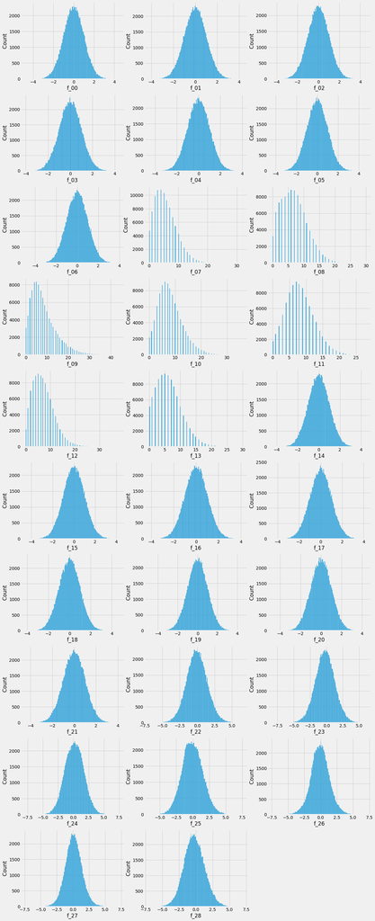

```python
plt.subplots(figsize=(18,50))
for i, col in enumerate(df.columns):
    plt.subplot(10, 3, i+1)
    sns.histplot(data=df, x=col)
```

Now, we will look at a correlation matrix and a heatmap of all of our features.

```python
# Show correlation matrix
df.corr()
```

|  | f_00 | f_01 | f_02 | f_03 | f_04 | f_05 | f_06 | f_07 | f_08 | f_09 | ... | f_19 | f_20 | f_21 | f_22 | f_23 | f_24 | f_25 | f_26 | f_27 | f_28 |
| --- | --- | --- | --- | --- | --- | --- | --- | --- | --- | --- | --- | --- | --- | --- | --- | --- | --- | --- | --- | --- | --- |
| f_00 | 1.000000 | -0.001955 | 0.002660 | 0.000105 | 0.008797 | 0.003817 | 0.002903 | -0.003847 | -0.000866 | -0.000976 | ... | 0.000437 | 0.002687 | -0.000447 | 0.004087 | -0.003756 | 0.001088 | 0.006216 | 0.000615 | 0.003888 | 0.001103 |
| f_01 | -0.001955 | 1.000000 | 0.001402 | -0.001698 | -0.001727 | -0.001444 | 0.001826 | 0.006539 | 0.001023 | 0.003428 | ... | -0.001402 | -0.001852 | 0.001099 | -0.002965 | 0.001760 | -0.005635 | 0.000033 | -0.001936 | 0.000229 | -0.005528 |
| f_02 | 0.002660 | 0.001402 | 1.000000 | -0.003271 | -0.000732 | -0.003743 | 0.003730 | 0.002603 | 0.004888 | -0.004690 | ... | -0.002743 | 0.002398 | -0.000301 | 0.004971 | 0.002971 | -0.002328 | 0.001797 | -0.001460 | 0.002210 | 0.000544 |
| f_03 | 0.000105 | -0.001698 | -0.003271 | 1.000000 | 0.000238 | 0.009835 | 0.002570 | -0.000562 | 0.000095 | 0.001626 | ... | 0.000540 | -0.005607 | 0.006154 | 0.001807 | 0.001241 | -0.002235 | 0.000362 | 0.002074 | 0.000427 | 0.001842 |
| f_04 | 0.008797 | -0.001727 | -0.000732 | 0.000238 | 1.000000 | 0.004550 | 0.004143 | 0.007164 | -0.002044 | 0.002025 | ... | 0.000731 | 0.000549 | -0.000956 | 0.003801 | -0.002564 | -0.000324 | -0.000765 | 0.002906 | 0.001421 | -0.003389 |
| f_05 | 0.003817 | -0.001444 | -0.003743 | 0.009835 | 0.004550 | 1.000000 | 0.004825 | 0.003289 | -0.002826 | -0.000695 | ... | 0.007995 | 0.000832 | -0.002269 | 0.002085 | -0.003774 | 0.002300 | 0.002087 | -0.001417 | -0.003124 | 0.002519 |
| f_06 | 0.002903 | 0.001826 | 0.003730 | 0.002570 | 0.004143 | 0.004825 | 1.000000 | -0.000300 | -0.005988 | 0.009750 | ... | -0.005252 | 0.000395 | -0.002691 | 0.000597 | -0.002754 | -0.002924 | -0.006603 | -0.000150 | -0.005421 | -0.000110 |
| f_07 | -0.003847 | 0.006539 | 0.002603 | -0.000562 | 0.007164 | 0.003289 | -0.000300 | 1.000000 | -0.131742 | 0.036707 | ... | 0.003504 | -0.002860 | -0.000085 | 0.003461 | -0.091825 | 0.030238 | 0.093444 | -0.017622 | -0.024546 | -0.022357 |
| f_08 | -0.000866 | 0.001023 | 0.004888 | 0.000095 | -0.002044 | -0.002826 | -0.005988 | -0.131742 | 1.000000 | -0.360734 | ... | 0.002888 | -0.001366 | -0.000753 | 0.072612 | 0.028442 | 0.011038 | 0.072565 | 0.085690 | -0.015953 | -0.029955 |
| f_09 | -0.000976 | 0.003428 | -0.004690 | 0.001626 | 0.002025 | -0.000695 | 0.009750 | 0.036707 | -0.360734 | 1.000000 | ... | 0.000224 | 0.003695 | 0.000747 | -0.123708 | -0.017430 | -0.014524 | -0.081116 | -0.085901 | -0.064825 | 0.018955 |
| f_10 | 0.002510 | 0.002071 | 0.004708 | -0.001752 | -0.003960 | 0.002807 | -0.004827 | -0.106755 | -0.051459 | 0.035432 | ... | -0.000655 | 0.001802 | 0.007463 | -0.022650 | 0.061926 | -0.016214 | -0.063222 | 0.034416 | 0.040545 | 0.015919 |
| f_11 | -0.000938 | -0.002024 | 0.001624 | 0.003533 | 0.000218 | -0.001368 | -0.004692 | -0.012389 | 0.179527 | -0.202523 | ... | 0.005591 | 0.001004 | -0.002893 | 0.034807 | 0.009575 | -0.006282 | 0.028018 | 0.002184 | -0.044690 | -0.011339 |
| f_12 | 0.004578 | -0.007009 | 0.003369 | -0.002081 | 0.001141 | -0.000530 | -0.001239 | -0.196534 | -0.076524 | -0.295563 | ... | -0.004642 | 0.000585 | -0.002922 | 0.053503 | -0.007275 | 0.015209 | -0.011212 | 0.001042 | 0.122341 | 0.030514 |
| f_13 | -0.001075 | -0.006544 | -0.000620 | -0.004417 | -0.000351 | -0.001335 | 0.000689 | -0.117606 | -0.014362 | -0.281970 | ... | -0.000901 | 0.002803 | -0.008525 | 0.032815 | 0.010538 | -0.012033 | 0.020166 | 0.019981 | -0.001665 | -0.012568 |
| f_14 | -0.003255 | -0.003968 | 0.002112 | 0.004566 | 0.001196 | 0.003204 | -0.000707 | 0.001908 | 0.000242 | 0.006359 | ... | -0.000835 | -0.000451 | 0.001578 | -0.001629 | 0.001980 | 0.000781 | -0.007537 | -0.002692 | -0.000292 | -0.003791 |
| f_15 | 0.005267 | -0.000157 | 0.005397 | 0.001454 | -0.002549 | -0.001235 | 0.004625 | 0.000890 | 0.000011 | 0.000875 | ... | -0.004414 | -0.002441 | 0.001769 | -0.004125 | -0.004534 | -0.004002 | 0.001268 | -0.003444 | 0.004094 | 0.004737 |
| f_16 | -0.001998 | 0.000941 | -0.003674 | -0.000372 | -0.003036 | 0.003359 | 0.003590 | 0.004975 | -0.006046 | -0.000845 | ... | 0.002479 | 0.001660 | 0.002605 | 0.003349 | -0.001059 | -0.000111 | 0.002177 | 0.008018 | -0.008543 | 0.003489 |
| f_17 | 0.005100 | -0.000327 | -0.002383 | 0.003240 | -0.002535 | -0.002734 | 0.004411 | -0.001435 | -0.000272 | -0.001134 | ... | 0.002548 | 0.002749 | -0.006562 | -0.001281 | -0.002004 | -0.000562 | 0.003564 | -0.004538 | 0.003680 | -0.002797 |
| f_18 | -0.000561 | 0.003146 | 0.006187 | 0.002039 | 0.000748 | 0.002783 | -0.006175 | -0.004443 | -0.000551 | 0.000692 | ... | 0.001414 | 0.004967 | 0.001448 | 0.000719 | 0.002199 | 0.002868 | -0.001085 | 0.000456 | -0.004012 | -0.001151 |
| f_19 | 0.000437 | -0.001402 | -0.002743 | 0.000540 | 0.000731 | 0.007995 | -0.005252 | 0.003504 | 0.002888 | 0.000224 | ... | 1.000000 | 0.002081 | 0.004865 | -0.003659 | 0.000045 | -0.001132 | -0.001998 | -0.000170 | -0.001780 | 0.001563 |
| f_20 | 0.002687 | -0.001852 | 0.002398 | -0.005607 | 0.000549 | 0.000832 | 0.000395 | -0.002860 | -0.001366 | 0.003695 | ... | 0.002081 | 1.000000 | 0.004519 | 0.000033 | 0.000338 | -0.000231 | 0.002113 | -0.004437 | -0.004339 | 0.001180 |
| f_21 | -0.000447 | 0.001099 | -0.000301 | 0.006154 | -0.000956 | -0.002269 | -0.002691 | -0.000085 | -0.000753 | 0.000747 | ... | 0.004865 | 0.004519 | 1.000000 | -0.002598 | -0.001129 | -0.002541 | -0.007879 | -0.001091 | 0.002864 | 0.002739 |
| f_22 | 0.004087 | -0.002965 | 0.004971 | 0.001807 | 0.003801 | 0.002085 | 0.000597 | 0.003461 | 0.072612 | -0.123708 | ... | -0.003659 | 0.000033 | -0.002598 | 1.000000 | 0.048009 | 0.117363 | -0.003846 | 0.112956 | 0.012242 | 0.026564 |
| f_23 | -0.003756 | 0.001760 | 0.002971 | 0.001241 | -0.002564 | -0.003774 | -0.002754 | -0.091825 | 0.028442 | -0.017430 | ... | 0.000045 | 0.000338 | -0.001129 | 0.048009 | 1.000000 | -0.016563 | -0.100514 | 0.122586 | 0.073208 | 0.098347 |
| f_24 | 0.001088 | -0.005635 | -0.002328 | -0.002235 | -0.000324 | 0.002300 | -0.002924 | 0.030238 | 0.011038 | -0.014524 | ... | -0.001132 | -0.000231 | -0.002541 | 0.117363 | -0.016563 | 1.000000 | -0.046221 | 0.042072 | -0.053663 | -0.078061 |
| f_25 | 0.006216 | 0.000033 | 0.001797 | 0.000362 | -0.000765 | 0.002087 | -0.006603 | 0.093444 | 0.072565 | -0.081116 | ... | -0.001998 | 0.002113 | -0.007879 | -0.003846 | -0.100514 | -0.046221 | 1.000000 | -0.057351 | -0.027863 | -0.026784 |
| f_26 | 0.000615 | -0.001936 | -0.001460 | 0.002074 | 0.002906 | -0.001417 | -0.000150 | -0.017622 | 0.085690 | -0.085901 | ... | -0.000170 | -0.004437 | -0.001091 | 0.112956 | 0.122586 | 0.042072 | -0.057351 | 1.000000 | 0.040819 | -0.012129 |
| f_27 | 0.003888 | 0.000229 | 0.002210 | 0.000427 | 0.001421 | -0.003124 | -0.005421 | -0.024546 | -0.015953 | -0.064825 | ... | -0.001780 | -0.004339 | 0.002864 | 0.012242 | 0.073208 | -0.053663 | -0.027863 | 0.040819 | 1.000000 | 0.052934 |
| f_28 | 0.001103 | -0.005528 | 0.000544 | 0.001842 | -0.003389 | 0.002519 | -0.000110 | -0.022357 | -0.029955 | 0.018955 | ... | 0.001563 | 0.001180 | 0.002739 | 0.026564 | 0.098347 | -0.078061 | -0.026784 | -0.012129 | 0.052934 | 1.000000 |

29 rows × 29 columns

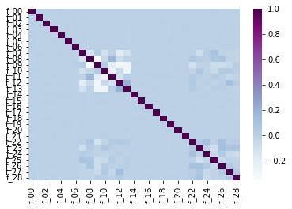

```python
# Show heatmap
sns.heatmap(df.corr(), cmap="BuPu", yticklabels=True)
```

We can see from the heatmap that there are not a lot of correlated features in our dataset.

## Data Munging

Next, I will perform some data munging / transforming on the dataset. Mainly, I will standardize all of the features. This will ensure that all of the features are scaled in the same way. This is very important in clustering since most algorithms use distance based metrics. Without scaling, high mean features would have a greater impact than low mean features.

In our case, we do not need to do any data cleaning or imputation since we have no missing values. This would normally be an important step in data science work.

```python
for col in df.columns:
  df[col] = (df[col] - df[col].mean()) / df[col].std()
```

```python
print(df.describe())
```

```
               f_00          f_01          f_02          f_03          f_04  \
count  9.800000e+04  9.800000e+04  9.800000e+04  9.800000e+04  9.800000e+04
mean  -2.958178e-17 -2.987180e-17 -2.204133e-17 -5.220314e-18  1.703852e-17
std    1.000000e+00  1.000000e+00  1.000000e+00  1.000000e+00  1.000000e+00
min   -4.720234e+00 -4.205255e+00 -4.369978e+00 -4.008433e+00 -4.518549e+00
25%   -6.745561e-01 -6.760634e-01 -6.708165e-01 -6.715564e-01 -6.769154e-01
50%    8.003339e-04  1.070092e-03  7.166146e-04 -2.483472e-03  2.138079e-04
75%    6.741632e-01  6.716680e-01  6.771977e-01  6.725128e-01  6.790321e-01
max    4.476763e+00  4.316193e+00  4.555035e+00  4.398216e+00  4.041698e+00

               f_05          f_06          f_07          f_08          f_09  \
count  9.800000e+04  9.800000e+04  9.800000e+04  9.800000e+04  9.800000e+04
mean   1.769106e-17  2.900174e-18 -9.019542e-17 -4.857792e-17  5.510331e-17
std    1.000000e+00  1.000000e+00  1.000000e+00  1.000000e+00  1.000000e+00
min   -4.296871e+00 -4.904069e+00 -1.502210e+00 -1.628732e+00 -1.387515e+00
25%   -6.730962e-01 -6.791225e-01 -6.896069e-01 -6.654214e-01 -7.101136e-01
50%    2.634601e-03  9.909674e-04 -1.478716e-01 -1.837662e-01 -2.020626e-01
75%    6.745973e-01  6.728807e-01  6.647313e-01  5.387166e-01  4.753388e-01
max    4.709424e+00  4.011933e+00  7.165554e+00  5.596096e+00  6.063900e+00

       ...          f_19          f_20          f_21          f_22  \
count  ...  9.800000e+04  9.800000e+04  9.800000e+04  9.800000e+04
mean   ...  1.580595e-17 -5.655340e-18 -1.406585e-17  7.105427e-18
std    ...  1.000000e+00  1.000000e+00  1.000000e+00  1.000000e+00
min    ... -4.868728e+00 -4.717746e+00 -4.437779e+00 -4.625104e+00
25%    ... -6.713255e-01 -6.772557e-01 -6.736769e-01 -6.659722e-01
50%    ...  3.908479e-03 -2.894663e-04  2.489450e-03 -1.213590e-02
75%    ...  6.737164e-01  6.739563e-01  6.787532e-01  6.556179e-01
max    ...  4.544891e+00  4.386895e+00  4.138319e+00  4.436470e+00

               f_23          f_24          f_25          f_26          f_27  \
count  9.800000e+04  9.800000e+04  9.800000e+04  9.800000e+04  9.800000e+04
mean  -1.377583e-17  1.935866e-17 -7.830471e-18 -3.625218e-18  4.350262e-18
std    1.000000e+00  1.000000e+00  1.000000e+00  1.000000e+00  1.000000e+00
min   -5.361327e+00 -5.157955e+00 -4.142880e+00 -5.121077e+00 -5.694797e+00
25%   -6.577323e-01 -6.933303e-01 -6.755071e-01 -6.394290e-01 -6.472781e-01
50%    6.397874e-04  4.149096e-04 -2.215128e-02 -5.820515e-03 -1.244209e-02
75%    6.587295e-01  6.811337e-01  6.674719e-01  6.342556e-01  6.333912e-01
max    4.197675e+00  4.770428e+00  4.827809e+00  4.949493e+00  5.444661e+00

               f_28
count  9.800000e+04
mean  -1.319579e-17
std    1.000000e+00
min   -4.398657e+00
25%   -6.749834e-01
50%   -2.643715e-02
75%    6.551792e-01
max    4.715848e+00

[8 rows x 29 columns]
```

We can see now that all of our data has now been standardized!

## Model Analysis

Now that we have performed our EDA and munged our data, we are ready to begin building models. For the purpose of this project, we will look at 3 different models, a K-means clustering model, a K-means clustering model aided with PCA, and a Gaussian Mixture Model.

## K-means Clustering

First, we will experiment with a K-means clustering model. I have chosen to use pyclustering over the more popular sklearn clustering, because pyclustering lets you change the distance metric for the model. This is an important hyperparameter that I would like to tune. The below code loops through 4 common distance metrics and reports the elbow score for each number of clusters from 1 to k. This will be useful in making our elbow plot.

```python
distance_measures = {'euclidean': 0, 'squared euclidean': 1, 'manhattan': 2,
                    'canberra': 5}
elbow = {}
#silhouttes = {}
for dist in distance_measures:
  elbow[dist] = []
  #silhouttes[dist] = []

  for k in range(1, 11):
    centers = kmeans_plusplus_initializer(df, k, random_state=seed).initialize()
    kmeans_instance = kmeans(df, centers, metric=distance_metric(distance_measures[dist]))
    kmeans_instance.process()
    clusters = kmeans_instance.get_clusters()
    elbow[dist].append(kmeans_instance.get_total_wce())

    if k > 1:
      clusters_list = [-1] * len(df_with_id['id'])
      for i in range(len(clusters)):
        for index in clusters[i]:
          clusters_list[index] = i

      #score = silhouette_score(df, clusters_list, metric=sk_learn_names[dist])
      #silhouttes[dist].append(score)

    print('Dist = {}, K = {}, Elbow = {}'.format(dist, k, elbow[dist][k-1]))
```

```
Dist = euclidean, K = 1, Elbow = 522303.38005058496
Dist = euclidean, K = 2, Elbow = 511699.30168531946
Dist = euclidean, K = 3, Elbow = 504440.4423675423
Dist = euclidean, K = 4, Elbow = 498849.71808545385
Dist = euclidean, K = 5, Elbow = 494505.3068245896
Dist = euclidean, K = 6, Elbow = 491499.2395492237
Dist = euclidean, K = 7, Elbow = 489040.1415014386
Dist = euclidean, K = 8, Elbow = 487130.7538186864
Dist = euclidean, K = 9, Elbow = 485006.63247709227
Dist = euclidean, K = 10, Elbow = 483226.51626268995
Dist = squared euclidean, K = 1, Elbow = 2841970.999999982
Dist = squared euclidean, K = 2, Elbow = 2727197.481576235
Dist = squared euclidean, K = 3, Elbow = 2650473.1839813553
Dist = squared euclidean, K = 4, Elbow = 2591947.3867234252
Dist = squared euclidean, K = 5, Elbow = 2546617.238045562
Dist = squared euclidean, K = 6, Elbow = 2516634.8381970203
Dist = squared euclidean, K = 7, Elbow = 2490457.866675674
Dist = squared euclidean, K = 8, Elbow = 2471353.2564838054
Dist = squared euclidean, K = 9, Elbow = 2449940.9426603434
Dist = squared euclidean, K = 10, Elbow = 2431522.8410312505
Dist = manhattan, K = 1, Elbow = 2260802.415422725
Dist = manhattan, K = 2, Elbow = 2203301.6807428976
Dist = manhattan, K = 3, Elbow = 2169409.9535511425
Dist = manhattan, K = 4, Elbow = 2142608.61409735
Dist = manhattan, K = 5, Elbow = 2120146.8344820812
Dist = manhattan, K = 6, Elbow = 2103694.298222031
Dist = manhattan, K = 7, Elbow = 2091837.4160804756
Dist = manhattan, K = 8, Elbow = 2081102.1060756345
Dist = manhattan, K = 9, Elbow = 2072523.7168357067
Dist = manhattan, K = 10, Elbow = 2064219.0730834245
Dist = canberra, K = 1, Elbow = 2842000.0
Dist = canberra, K = 2, Elbow = 2842000.0
Dist = canberra, K = 3, Elbow = 2679908.8889076104
Dist = canberra, K = 4, Elbow = 2431531.1383515364
Dist = canberra, K = 5, Elbow = 2389814.0951206028
Dist = canberra, K = 6, Elbow = 2293611.668147451
Dist = canberra, K = 7, Elbow = 2103652.78282968
Dist = canberra, K = 8, Elbow = 2071001.6999948123
Dist = canberra, K = 9, Elbow = 2058535.7356736
Dist = canberra, K = 10, Elbow = 2034258.510523001
```

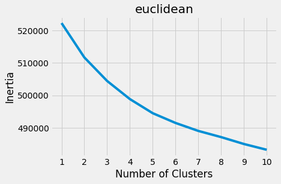

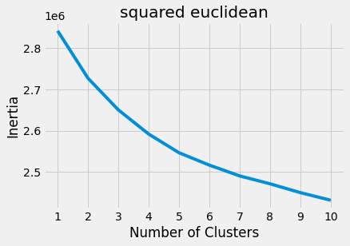

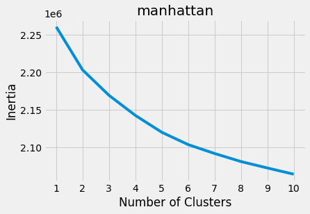

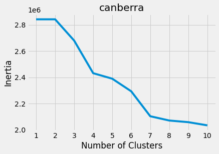

```python
for dist in distance_measures:
  plt.style.use("fivethirtyeight")
  plt.plot(range(1, 11), elbow[dist])
  plt.xticks(range(1, 11))
  plt.xlabel("Number of Clusters")
  plt.ylabel("Inertia")
  plt.title(dist)
  plt.show()
```

As you can see, the best distance metrics appears to be the euclidean distance. Additionally, the elbow point appears to be at k = 7.

We can create a model with those metrics and pass it to the kaggle api to get a test score.

```python
centers = kmeans_plusplus_initializer(df, 7, random_state=seed).initialize()
kmeans_instance = kmeans(df, centers, metric=distance_metric(0))
kmeans_instance.process()
clusters = kmeans_instance.get_clusters()

results = pd.DataFrame()
results['Id'] = df_with_id['id']

clusters_list = [-1] * len(df_with_id['id'])

for i in range(len(clusters)):
  for index in clusters[i]:
    clusters_list[index] = i

results['Predicted'] = clusters_list

results.to_csv('k_means_output.csv', index=False)
```

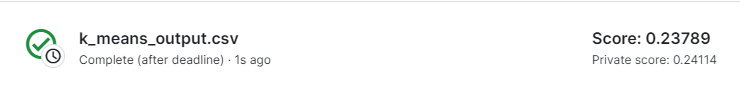

As you can see, our accuracy score was 0.238. This is not very good so we will see if we can improve it with the help of PCA.

## K-means clustering with PCA

It is a well known problem that K-means clustering can suffer from the curse of dimensionality. Maybe our 29 features are too many? In an attempt to solve this, we can look at reducing our features through PCA.

```python
pca = PCA(n_components=25)
pca.fit_transform(df)
pca.explained_variance_ratio_.cumsum()
```

```
array([0.06270482, 0.11301871, 0.15849873, 0.19862481, 0.23728464,
       0.27389417, 0.30909898, 0.34417689, 0.37922249, 0.41408223,
       0.44887732, 0.48349173, 0.5180389 , 0.55252544, 0.58694135,
       0.62128275, 0.6555482 , 0.68963221, 0.72360847, 0.75741177,
       0.79113585, 0.82403683, 0.85579202, 0.88472494, 0.91301555])
```

The above cell indicates that over 58% of the variance can be explained with only 15 features. We will try reducing the features to 15, fitting another k-means clustering model, and seeing if that improves our results.

```python
pca = PCA(n_components=15)
pcs = pca.fit_transform(df)
```

```python
distance_measures = {'euclidean': 0, 'squared euclidean': 1, 'manhattan': 2,
                    'canberra': 5}

elbow = {}
for dist in distance_measures:
  elbow[dist] = []

  for k in range(1, 11):
    centers = kmeans_plusplus_initializer(pcs, k, random_state=seed).initialize()
    kmeans_instance = kmeans(pcs, centers, metric=distance_metric(distance_measures[dist]))
    kmeans_instance.process()
    clusters = kmeans_instance.get_clusters()
    elbow[dist].append(kmeans_instance.get_total_wce())

    print('Dist = {}, K = {}, Elbow = {}'.format(dist, k, elbow[dist][k-1]))
```

```
Dist = euclidean, K = 1, Elbow = 396653.32629957236
Dist = euclidean, K = 2, Elbow = 382817.810799324
Dist = euclidean, K = 3, Elbow = 373355.6247642062
Dist = euclidean, K = 4, Elbow = 366242.5786447109
Dist = euclidean, K = 5, Elbow = 360810.39662534394
Dist = euclidean, K = 6, Elbow = 356908.9285856111
Dist = euclidean, K = 7, Elbow = 353925.00525946775
Dist = euclidean, K = 8, Elbow = 351421.79102963954
Dist = euclidean, K = 9, Elbow = 349512.26847287914
Dist = euclidean, K = 10, Elbow = 347691.8469164516
Dist = squared euclidean, K = 1, Elbow = 1663504.4513962427
Dist = squared euclidean, K = 2, Elbow = 1549147.7672594145
Dist = squared euclidean, K = 3, Elbow = 1473801.5797790047
Dist = squared euclidean, K = 4, Elbow = 1418018.6826509766
Dist = squared euclidean, K = 5, Elbow = 1376099.1517409263
Dist = squared euclidean, K = 6, Elbow = 1347005.981112795
Dist = squared euclidean, K = 7, Elbow = 1324870.869012426
Dist = squared euclidean, K = 8, Elbow = 1306626.55163299
Dist = squared euclidean, K = 9, Elbow = 1291960.8636672087
Dist = squared euclidean, K = 10, Elbow = 1278573.493779408
Dist = manhattan, K = 1, Elbow = 1240888.1676958834
Dist = manhattan, K = 2, Elbow = 1200592.4546831527
Dist = manhattan, K = 3, Elbow = 1169739.054767307
Dist = manhattan, K = 4, Elbow = 1146039.0369550479
Dist = manhattan, K = 5, Elbow = 1126421.3744840045
Dist = manhattan, K = 6, Elbow = 1113737.6793724261
Dist = manhattan, K = 7, Elbow = 1102331.8072859317
Dist = manhattan, K = 8, Elbow = 1095329.1702727075
Dist = manhattan, K = 9, Elbow = 1087772.1487070168
Dist = manhattan, K = 10, Elbow = 1080689.4778504043
Dist = canberra, K = 1, Elbow = 1470000.0
Dist = canberra, K = 2, Elbow = 1469781.2144442461
Dist = canberra, K = 3, Elbow = 1146603.620900711
Dist = canberra, K = 4, Elbow = 1073916.6585340768
Dist = canberra, K = 5, Elbow = 1048531.9688813224
Dist = canberra, K = 6, Elbow = 1002864.4447110196
Dist = canberra, K = 7, Elbow = 970888.5572657529
Dist = canberra, K = 8, Elbow = 948458.466446549
Dist = canberra, K = 9, Elbow = 934639.6807477352
Dist = canberra, K = 10, Elbow = 922560.366111116
```

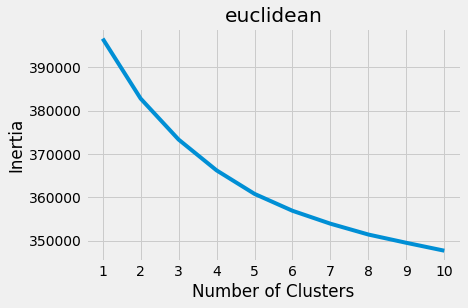

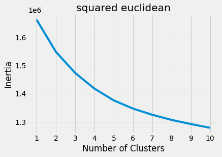

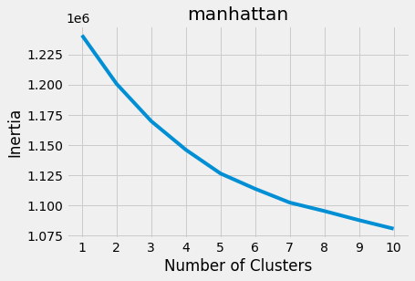

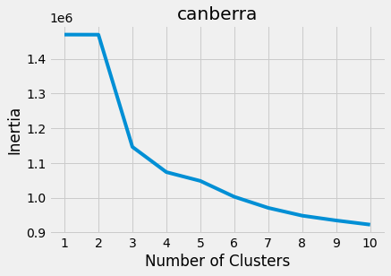

```python
for dist in distance_measures:
  plt.style.use("fivethirtyeight")
  plt.plot(range(1, 11), elbow[dist])
  plt.xticks(range(1, 11))
  plt.xlabel("Number of Clusters")
  plt.ylabel("Inertia")
  plt.title(dist)
  plt.show()
```

No surprise, but it again appears that the euclidean distance metric performed the best and k = 7 still appears to be a good choice. We can train another model using the 15 principal components and pass it to the kaggle api.

```python
centers = kmeans_plusplus_initializer(pcs, 7, random_state=seed).initialize()
kmeans_instance = kmeans(pcs, centers, metric=distance_metric(0))
kmeans_instance.process()
clusters = kmeans_instance.get_clusters()

results = pd.DataFrame()
results['Id'] = df_with_id['id']

clusters_list = [-1] * len(df_with_id['id'])

for i in range(len(clusters)):
  for index in clusters[i]:
    clusters_list[index] = i

results['Predicted'] = clusters_list

results.to_csv('k_means_pca_output.csv', index=False)
```

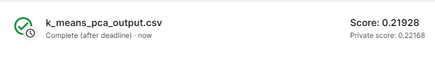

As you can see, our accuracy score went down to 0.219. It appears that the explained variance that was lost could not be overcome by the smaller number of features. So far, our k-means clustering algorithms have not perform too well. We will now look to using a Gaussian Mixture Model.

## Gaussian Mixture Model

We did not cover gaussian mixture models in this class, but they are powerful clustering models that can solve a variety of problems. Here is a brief description with a comparison to the k-means clustering algorithim.

Gaussian Mixture Models (GMMs), assume that each data point is generated from a mixture of Gaussian distributions. It attempts to estimate the number of data points that come from each underlying gaussian distribution. Some key differences between GMMs and K-means clustering are:

- GMMs are much more flexible. They can detect clusters of any shape while K-means is limited to spherical clusters.
- GMMs perform better when the clusters are not clearly seperated and defined.
- GMMs can handle missing data, while k-means can not.
- GMMs take into account the variance of the data, while k-means does not
- GMMs assign a probablity for each data point for each class. This is more information than can be extracted from a k-means clustering algorithm.

All in all, GMMs are very powerful clustering models and I recommend studying them more. Here is an article that I found helpful https://vitalflux.com/gaussian-mixture-models-what-are-they-when-to-use/

For my model analysis, I will be using sklearn's Gaussian Mixture Model. Additionally, one key hyperparameter is the covariance matrix type. Similar to the k-means clustering, I will generate plots comparing all of the covariance matrix types for k = 1,10

```python
covariance_types = ['full', 'tied', 'diag', 'spherical']
bics = {}
aics = {}

for cov_type in covariance_types:
  bics[cov_type] = []
  aics[cov_type] = []
  for k in range(1, 11):
    n_clusters = k
    gm_model = GaussianMixture(n_components=n_clusters, covariance_type=cov_type, random_state=seed)
    gm_model.fit(df)
    bics[cov_type].append(gm_model.bic(df))
    aics[cov_type].append(gm_model.aic(df))

    print('cov_type = {}, K = {}, Bic = {}, Aic = {}'.format(cov_type, k, bics[cov_type][k-1], aics[cov_type][k-1]))
```

```
cov_type = full, K = 1, Bic = 7976571.319948509, Aic = 7972166.696588959
cov_type = full, K = 2, Bic = 7902757.11474766, Aic = 7893938.375305801
cov_type = full, K = 3, Bic = 7875073.548948538, Aic = 7861840.69342437
cov_type = full, K = 4, Bic = 7856451.224023618, Aic = 7838804.252417142
cov_type = full, K = 5, Bic = 7844763.061388693, Aic = 7822701.973699908
cov_type = full, K = 6, Bic = 7829793.596065795, Aic = 7803318.392294701
cov_type = full, K = 7, Bic = 7829870.398682252, Aic = 7798981.07882885
cov_type = full, K = 8, Bic = 7819753.991819145, Aic = 7784450.555883435
cov_type = full, K = 9, Bic = 7817969.07687381, Aic = 7778251.524855791
cov_type = full, K = 10, Bic = 7818760.27438424, Aic = 7774628.606283912
cov_type = tied, K = 1, Bic = 7976571.319948509, Aic = 7972166.696588959
cov_type = tied, K = 2, Bic = 7950137.075511686, Aic = 7945447.670469405
cov_type = tied, K = 3, Bic = 7946702.227181154, Aic = 7941728.040456144
cov_type = tied, K = 4, Bic = 7936083.571482613, Aic = 7930824.603074873
cov_type = tied, K = 5, Bic = 7927876.318851926, Aic = 7922332.568761457
cov_type = tied, K = 6, Bic = 7920878.126615656, Aic = 7915049.594842457
cov_type = tied, K = 7, Bic = 7918875.232533925, Aic = 7912761.919077997
cov_type = tied, K = 8, Bic = 7908613.959877672, Aic = 7902215.864739014
cov_type = tied, K = 9, Bic = 7900357.039455698, Aic = 7893674.16263431
cov_type = tied, K = 10, Bic = 7902777.117309231, Aic = 7895809.458805114
cov_type = diag, K = 1, Bic = 8065884.200508764, Aic = 8065333.62258882
cov_type = diag, K = 2, Bic = 7988261.792570862, Aic = 7987151.144008216
cov_type = diag, K = 3, Bic = 7946701.735906543, Aic = 7945031.016701196
cov_type = diag, K = 4, Bic = 7926760.998121253, Aic = 7924530.208273205
cov_type = diag, K = 5, Bic = 7899404.30358381, Aic = 7896613.4430930605
cov_type = diag, K = 6, Bic = 7880007.448837465, Aic = 7876656.517704013
cov_type = diag, K = 7, Bic = 7875831.167049612, Aic = 7871920.165273459
cov_type = diag, K = 8, Bic = 7866533.519391973, Aic = 7862062.446973118
cov_type = diag, K = 9, Bic = 7856449.937072867, Aic = 7851418.794011311
cov_type = diag, K = 10, Bic = 7849206.328548483, Aic = 7843615.114844225
cov_type = spherical, K = 1, Bic = 8065562.40427155, Aic = 8065277.62258882
cov_type = spherical, K = 2, Bic = 8029556.76996375, Aic = 8028977.713875533
cov_type = spherical, K = 3, Bic = 8017031.690622544, Aic = 8016158.3601288395
cov_type = spherical, K = 4, Bic = 8007019.979604425, Aic = 8005852.374705234
cov_type = spherical, K = 5, Bic = 7998777.860985319, Aic = 7997315.981680641
cov_type = spherical, K = 6, Bic = 7993841.066729614, Aic = 7992084.913019448
cov_type = spherical, K = 7, Bic = 7990302.382545289, Aic = 7988251.954429636
cov_type = spherical, K = 8, Bic = 7986307.190716902, Aic = 7983962.488195762
cov_type = spherical, K = 9, Bic = 7984574.763824274, Aic = 7981935.786897646
cov_type = spherical, K = 10, Bic = 7980426.7785316175, Aic = 7977493.527199503
```

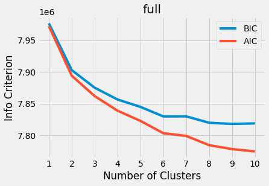

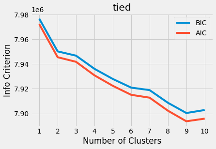

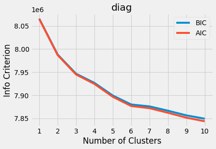

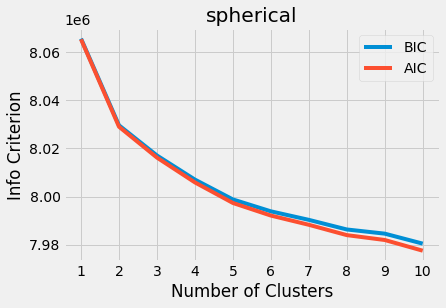

```python
for cov_type in covariance_types:
  plt.style.use("fivethirtyeight")
  plt.plot(range(1, 11), bics[cov_type], label='BIC')
  plt.plot(range(1, 11), aics[cov_type], label='AIC')
  plt.xticks(range(1, 11))
  plt.xlabel("Number of Clusters")
  plt.ylabel("Info Criterion")
  plt.legend(loc='upper right')
  plt.title(cov_type)
  plt.show()
```

```python
gm_model = GaussianMixture(n_components=8, random_state=seed, covariance_type='full')
gm_model.fit(df)
cluster_labels = gm_model.predict(df)

results = pd.DataFrame()
results['Id'] = df_with_id['id']
results['Predicted'] = cluster_labels

results.to_csv('gaussian_mixture_output.csv', index=False)
```

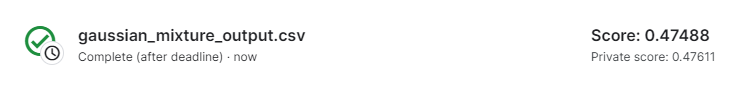

This produced an accuracy score of 0.475. This is much better than our k-means clustering models so it appears that our clusters are either non spherical or not super well defined as this is when GMMs thrive. For a completely unsupervised problem, 0.475 is not a bad accuracy score. However, I have one more idea that I would like to try.

## Feature Reduction with GMMs

In my research of GMMs for this project, I came across multiple sources that indicated that features with high variance are the most helpful for GMMs. I remember from my EDA, that some of our parameters started out with much more variance than others. I will load the data again and take another look!

```python
df_with_id = pd.read_csv("data.csv")
df_high_var = df_with_id.drop(columns='id')
```

```python
for col in df_high_var.columns:
  print('{} std dev = {}'.format(col, df_high_var[col].std()))
```

```
f_00 std dev = 1.0028008443406387
f_01 std dev = 1.0007417893509403
f_02 std dev = 1.0013731406044029
f_03 std dev = 1.000422331364304
f_04 std dev = 1.0030612576721685
f_05 std dev = 1.0005316032947835
f_06 std dev = 0.9974337077545695
f_07 std dev = 3.6918401432306363
f_08 std dev = 4.15234814762191
f_09 std dev = 5.904918641071406
f_10 std dev = 4.700225581485239
f_11 std dev = 4.197106310853215
f_12 std dev = 4.433308314004286
f_13 std dev = 4.120076834547958
f_14 std dev = 0.9989396027508508
f_15 std dev = 1.0010959008799138
f_16 std dev = 1.003277006429853
f_17 std dev = 1.001257526011278
f_18 std dev = 0.995965248274986
f_19 std dev = 1.0043718031633782
f_20 std dev = 1.0029619378365018
f_21 std dev = 0.9997028161384486
f_22 std dev = 1.477858183368349
f_23 std dev = 1.4948355190687004
f_24 std dev = 1.5430139689935576
f_25 std dev = 1.5760855408956322
f_26 std dev = 1.4280548306058654
f_27 std dev = 1.3054070609812956
f_28 std dev = 1.5284759392507545
```

Yes, the above output shows that there are a handful of features with std deviations greater than 1.01. We will reduce our data to just these features.

```python
for col in df_high_var.columns:
  if df_high_var[col].std() < 1.1:
    df_high_var = df_high_var.drop(columns=col)


print(df_high_var.shape)
df_high_var.describe()
```

```
(98000, 14)
```

|  | f_07 | f_08 | f_09 | f_10 | f_11 | f_12 | f_13 | f_22 | f_23 | f_24 | f_25 | f_26 | f_27 | f_28 |
| --- | --- | --- | --- | --- | --- | --- | --- | --- | --- | --- | --- | --- | --- | --- |
| count | 98000.000000 | 98000.000000 | 98000.000000 | 98000.000000 | 98000.000000 | 98000.000000 | 98000.000000 | 98000.000000 | 98000.000000 | 98000.000000 | 98000.000000 | 98000.000000 | 98000.000000 | 98000.000000 |
| mean | 5.545918 | 6.763061 | 8.193163 | 8.057878 | 8.084990 | 7.076388 | 6.286102 | -0.038752 | -0.220002 | 0.166434 | -0.064309 | -0.062540 | 0.098472 | -0.230910 |
| std | 3.691840 | 4.152348 | 5.904919 | 4.700226 | 4.197106 | 4.433308 | 4.120077 | 1.477858 | 1.494836 | 1.543014 | 1.576086 | 1.428055 | 1.305407 | 1.528476 |
| min | 0.000000 | 0.000000 | 0.000000 | 0.000000 | 0.000000 | 0.000000 | 0.000000 | -6.873999 | -8.234305 | -7.792363 | -6.593842 | -7.375719 | -7.335556 | -6.954151 |
| 25% | 3.000000 | 4.000000 | 4.000000 | 5.000000 | 5.000000 | 4.000000 | 3.000000 | -1.022964 | -1.203204 | -0.903385 | -1.128966 | -0.975680 | -0.746489 | -1.262606 |
| 50% | 5.000000 | 6.000000 | 7.000000 | 7.000000 | 8.000000 | 6.000000 | 6.000000 | -0.056687 | -0.219046 | 0.167074 | -0.099221 | -0.070852 | 0.082230 | -0.271319 |
| 75% | 8.000000 | 9.000000 | 11.000000 | 11.000000 | 11.000000 | 10.000000 | 9.000000 | 0.930158 | 0.764690 | 1.217432 | 0.987684 | 0.843212 | 0.925306 | 0.770516 |
| max | 32.000000 | 30.000000 | 44.000000 | 36.000000 | 28.000000 | 38.000000 | 30.000000 | 6.517721 | 6.054831 | 7.527271 | 7.544731 | 7.005608 | 7.205971 | 6.977150 |

You can now see that we are left with only 14 features. These are all of our features with a lot of variability. Now, we will standardize the features so that any distance calculations are not skewed.

```python
for col in df_high_var.columns:
  df_high_var[col] = (df_high_var[col] - df_high_var[col].mean()) / df_high_var[col].std()
```

Now, we can set up our GMM fit with the different covariance types the same as we did before.

```python
covariance_types = ['full', 'tied', 'diag', 'spherical']
bics = {}
aics = {}

for cov_type in covariance_types:
  bics[cov_type] = []
  aics[cov_type] = []
  for k in range(1, 11):
    n_clusters = k
    gm_model = GaussianMixture(n_components=n_clusters, covariance_type=cov_type, random_state=seed)
    gm_model.fit(df_high_var)
    bics[cov_type].append(gm_model.bic(df_high_var))
    aics[cov_type].append(gm_model.aic(df_high_var))

    print('cov_type = {}, K = {}, Bic = {}, Aic = {}'.format(cov_type, k, bics[cov_type][k-1], aics[cov_type][k-1]))
```

```
cov_type = full, K = 1, Bic = 10551010.42803471, Aic = 10546605.804675158
cov_type = full, K = 2, Bic = 10477494.91102645, Aic = 10468676.171584591
cov_type = full, K = 3, Bic = 10450054.12651384, Aic = 10436821.270989673
cov_type = full, K = 4, Bic = 10428076.342457943, Aic = 10410429.370851466
cov_type = full, K = 5, Bic = 10418473.076769855, Aic = 10396411.98908107
cov_type = full, K = 6, Bic = 10406953.201923922, Aic = 10380477.998152828
cov_type = full, K = 7, Bic = 10394012.608390851, Aic = 10363123.288537448
cov_type = full, K = 8, Bic = 10395002.569069065, Aic = 10359699.133133356
cov_type = full, K = 9, Bic = 10392662.000279136, Aic = 10352944.448261118
cov_type = full, K = 10, Bic = 10391502.490906157, Aic = 10347370.82280583
cov_type = tied, K = 1, Bic = 10551010.42803471, Aic = 10546605.804675158
cov_type = tied, K = 2, Bic = 10524624.100821134, Aic = 10519934.695778854
cov_type = tied, K = 3, Bic = 10521404.233493038, Aic = 10516430.046768028
cov_type = tied, K = 4, Bic = 10509817.32952317, Aic = 10504558.361115431
cov_type = tied, K = 5, Bic = 10502700.065846425, Aic = 10497156.315755956
cov_type = tied, K = 6, Bic = 10492048.653468583, Aic = 10486220.121695384
cov_type = tied, K = 7, Bic = 10483955.925890984, Aic = 10477842.612435056
cov_type = tied, K = 8, Bic = 10482650.50160098, Aic = 10476252.406462323
cov_type = tied, K = 9, Bic = 10476275.058008024, Aic = 10469592.181186637
cov_type = tied, K = 10, Bic = 10474085.089097, Aic = 10467117.430592883
cov_type = diag, K = 1, Bic = 10640323.308595402, Aic = 10639772.730675459
cov_type = diag, K = 2, Bic = 10562123.826454533, Aic = 10561013.177891888
cov_type = diag, K = 3, Bic = 10521286.352763528, Aic = 10519615.633558182
cov_type = diag, K = 4, Bic = 10493217.670722911, Aic = 10490986.880874863
cov_type = diag, K = 5, Bic = 10472315.377954584, Aic = 10469524.517463833
cov_type = diag, K = 6, Bic = 10459928.211320763, Aic = 10456577.280187313
cov_type = diag, K = 7, Bic = 10444593.432283523, Aic = 10440682.43050737
cov_type = diag, K = 8, Bic = 10438405.22595627, Aic = 10433934.153537417
cov_type = diag, K = 9, Bic = 10427759.775828185, Aic = 10422728.632766629
cov_type = diag, K = 10, Bic = 10421809.510500576, Aic = 10416218.296796318
cov_type = spherical, K = 1, Bic = 13132609.042262983, Aic = 13132324.260580253
cov_type = spherical, K = 2, Bic = 12708513.54729525, Aic = 12707934.491207033
cov_type = spherical, K = 3, Bic = 12507081.132774629, Aic = 12506207.802280925
cov_type = spherical, K = 4, Bic = 12320856.728404246, Aic = 12319689.123505056
cov_type = spherical, K = 5, Bic = 12168782.857753033, Aic = 12167320.978448354
cov_type = spherical, K = 6, Bic = 12077109.61250559, Aic = 12075353.458795425
cov_type = spherical, K = 7, Bic = 12005096.52639745, Aic = 12003046.098281797
cov_type = spherical, K = 8, Bic = 11949119.409923607, Aic = 11946774.707402468
cov_type = spherical, K = 9, Bic = 11889729.56724622, Aic = 11887090.590319593
cov_type = spherical, K = 10, Bic = 11847440.237552261, Aic = 11844506.986220146
```

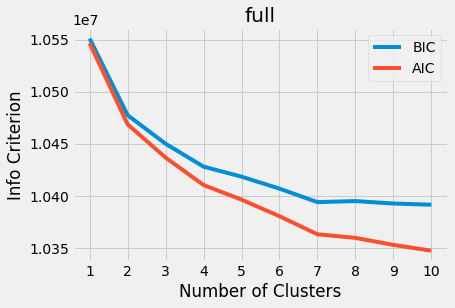

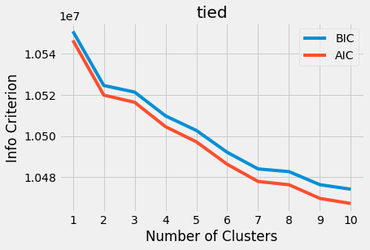

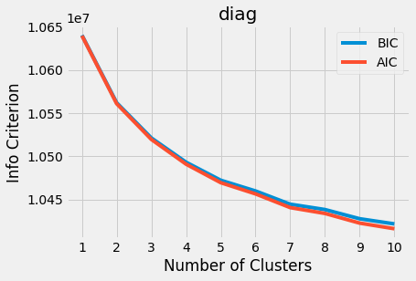

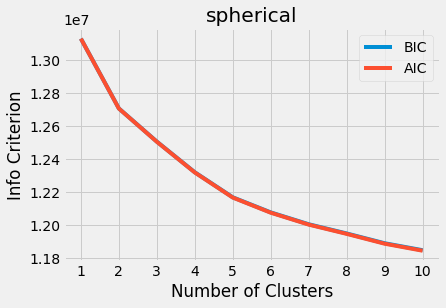

```python
for cov_type in covariance_types:
  plt.style.use("fivethirtyeight")
  plt.plot(range(1, 11), bics[cov_type], label='BIC')
  plt.plot(range(1, 11), aics[cov_type], label='AIC')
  plt.xticks(range(1, 11))
  plt.xlabel("Number of Clusters")
  plt.ylabel("Info Criterion")
  plt.legend(loc='upper right')
  plt.title(cov_type)
  plt.show()
```

Again, we can see that the best model using the full covariance matrix and has k = 7. We can create a model with those options and pass it to the kaggle api.

```python
gm_model = GaussianMixture(n_components=7, random_state=seed, covariance_type='full')
gm_model.fit(df_high_var)
cluster_labels = gm_model.predict(df_high_var)

results = pd.DataFrame()
results['Id'] = df_with_id['id']
results['Predicted'] = cluster_labels

results.to_csv('gaussian_mixture_output_feature_selection.csv', index=False)
```

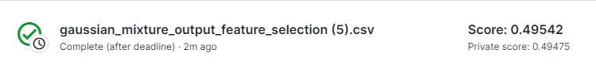

This resulted in an accuracy score of 0.495 which is an improvement over the previous GMM model. All in all, it seems that GMM is the way to go for this problem!

## Conclusion

For my DTSA 5510 Final Project, I attempted to solve a clustering problem from a publicly available kaggle dataset. This problem was a great chance for me to grow in my clustering abilities. In total, I experimented with:

- K-means clustering
- K-means clustering with PCA
- Gaussian Mixture Models
- Gaussian Mixture Models with only high variability features

The best performing cluster model was the last one, the GMM with only high variability features. This seems to indicate that there are a handful of features that are more important for this clustering task than the others. Additionally, the success of the GMM when compared the k-means model indicates that the clusters are not well defined and not spherical.

Overall, this was a great problem to work on, and I now feel much more skilled with clustering!

## Future Work

If I had more time, these are some of the things that I would add to this project. These are future work ideas that would benefit this project!

- Using the silhoutte score to compare the GMMs and k-means clustering models. In the real world, the kaggle accuracy score would not be available so the silhoutte score would help compare different model types.
- Experimenting with Bayesian GMMs. These are GMMs that can affectively deduce k on their own.
- Conducting more GMM experiments with different combinations of the high variability features.